# Exploring Survival on the Titanic - Part 1

Rick Dean

12/14/2019

```r
library(here)
library(tidyr)
library(readr)
library(stringr)
library(dplyr)
library(ggplot2)
library(mice)
library(randomForest)
library(RplotterPkg)

here::here()
## [1] "C:/Code_R/projects/R_Exploring_Survival_on_the_Titanic_rmd"
```

# 1 Introduction

The following analysis is based on the R [script](https://www.kaggle.com/mrisdal/exploring-survival-on-the-titanic/code) presented by Megan L. Risdal on [Kaggle](https://www.kaggle.com) along with data [descriptions](https://www.kaggle.com/c/titanic/data).

Additional analysis using decision trees and randomForest is provided by [Titanic: Getting started with R](https://trevorstephens.com/kaggle-titanic-tutorial/getting-started-with-r/) by Trevor Stephens.

The Titantic data originated from the [Vanderbilt Biostat Department](http://biostat.mc.vanderbilt.edu/wiki/pub/Main/DataSets/titanic3.xls)

# 2 Load and check data

Task: Read the csv file that has all 1309 passengers with recorded data.

```r
full_df <- readr::read_csv("data/titanic_full.csv", n_max = 1309)
glimpse(full_df)
## Observations: 1,309
## Variables: 14
## $ pclass    <dbl> 1, 1, 1, 1, 1, 1, 1, 1, 1, 1, 1, 1, 1, 1, 1, 1, 1, 1, 1, ...
## $ survived  <dbl> 1, 1, 0, 0, 0, 1, 1, 0, 1, 0, 0, 1, 1, 1, 1, 0, 0, 1, 1, ...
## $ name      <chr> "Allen, Miss. Elisabeth Walton", "Allison, Master. Hudson...
## $ sex       <chr> "female", "male", "female", "male", "female", "male", "fe...
## $ age       <dbl> 29.0000, 0.9167, 2.0000, 30.0000, 25.0000, 48.0000, 63.00...
## $ sibsp     <dbl> 0, 1, 1, 1, 1, 0, 1, 0, 2, 0, 1, 1, 0, 0, 0, 0, 0, 0, 0, ...
## $ parch     <dbl> 0, 2, 2, 2, 2, 0, 0, 0, 0, 0, 0, 0, 0, 0, 0, 0, 1, 1, 0, ...
## $ ticket    <chr> "24160", "113781", "113781", "113781", "113781", "19952",...
## $ fare      <dbl> 211.3375, 151.5500, 151.5500, 151.5500, 151.5500, 26.5500...
## $ cabin     <chr> "B5", "C22 C26", "C22 C26", "C22 C26", "C22 C26", "E12", ...
## $ embarked  <chr> "S", "S", "S", "S", "S", "S", "S", "S", "S", "C", "C", "C...
## $ boat      <chr> "2", "11", NA, NA, NA, "3", "10", NA, "D", NA, NA, "4", "...
## $ body      <dbl> NA, NA, NA, 135, NA, NA, NA, NA, NA, 22, 124, NA, NA, NA,...
## $ home.dest <chr> "St Louis, MO", "Montreal, PQ / Chesterville, ON", "Montr...
```

# 3 Add new variables

## 3.1 Add a passenger_id column

```r
full_df <- full_df %>%
  mutate(passenger_id = seq(from = 1, to = 1309, by=1))
```

## 3.2 Add *title* column

Task: Add *title* column to full_df.

```r
full_df$title <- str_replace(full_df$name, ".+, ","")
full_df$title <- str_replace(full_df$title, "\\. .+", "")
```

Task: Look at frequency of various female titles.

```r
females_df <- full_df %>%
  filter(sex == "female")
table(females_df$title)
##
##         Dona           Dr         Lady         Miss         Mlle          Mme
##            1            1            1          260            2            1
##          Mrs           Ms the Countess
##          197            2            1
```

Task: Correct *title* for females.

```r
full_df$title <- if_else(full_df$title %in% c("Dona","Lady","Mme","the Countess"), "Mrs", full_df$title)
full_df$title <- if_else(full_df$title %in% c("Mlle","Ms"), "Miss", full_df$title)
full_df$title <- if_else(full_df$sex == "female" & full_df$title == "Dr", "Mrs", full_df$title)
```

Task: Check frequency of *title* for females again.

```r
females_df <- full_df %>%
  filter(sex == "female")
table(females_df$title)
##
## Miss  Mrs
##  264  202
```

Task: Look at frequency of various male titles.

```r
males_df <- full_df %>%
  filter(sex == "male")
table(males_df$title)
##
##     Capt      Col      Don       Dr Jonkheer    Major   Master       Mr
##        1        4        1        7        1        2       61      757
##      Rev      Sir
##        8        1
```

Task: Correct *title* for males.

```r
full_df$title <- if_else(full_df$title %in% c("Capt","Col","Don","Dr","Jonkheer","Major","Master","Rev","Sir"), "Mr", full_df$title)
```

Task: Check frequency of *title* for males again.

```r
males_df <- full_df %>%
  filter(sex == "male")
table(males_df$title)
##
##  Mr
## 843
```

## 3.3 Add *surname* column

Task: Create a *surname* column.

```r
full_df$surname <- str_split(full_df$name, ", ", simplify = TRUE)[,1]
```

## 3.4 Add *family_size* column

Task: Create a *family_size* column.

```r
full_df$family_size <- full_df$sibsp + full_df$parch + 1
```

## 3.5 Add *family* column

Task: Create a *family* column.

```r
full_df$family <- paste(full_df$surname, full_df$family_size, sep = "_")
```

## 3.6 Add *deck* column

Task: Create a *deck* column.

```r
full_df$deck <- str_split(full_df$cabin, "", simplify = TRUE)[,1]
```

## 3.7 Review *full_df*

Task: Review *full_df* data frame.

```r
glimpse(full_df)
## Observations: 1,309
## Variables: 20
## $ pclass       <dbl> 1, 1, 1, 1, 1, 1, 1, 1, 1, 1, 1, 1, 1, 1, 1, 1, 1, 1, ...
## $ survived     <dbl> 1, 1, 0, 0, 0, 1, 1, 0, 1, 0, 0, 1, 1, 1, 1, 0, 0, 1, ...
## $ name         <chr> "Allen, Miss. Elisabeth Walton", "Allison, Master. Hud...
## $ sex          <chr> "female", "male", "female", "male", "female", "male", ...
## $ age          <dbl> 29.0000, 0.9167, 2.0000, 30.0000, 25.0000, 48.0000, 63...
## $ sibsp        <dbl> 0, 1, 1, 1, 1, 0, 1, 0, 2, 0, 1, 1, 0, 0, 0, 0, 0, 0, ...
## $ parch        <dbl> 0, 2, 2, 2, 2, 0, 0, 0, 0, 0, 0, 0, 0, 0, 0, 0, 1, 1, ...
## $ ticket       <chr> "24160", "113781", "113781", "113781", "113781", "1995...
## $ fare         <dbl> 211.3375, 151.5500, 151.5500, 151.5500, 151.5500, 26.5...
## $ cabin        <chr> "B5", "C22 C26", "C22 C26", "C22 C26", "C22 C26", "E12...
## $ embarked     <chr> "S", "S", "S", "S", "S", "S", "S", "S", "S", "C", "C",...
## $ boat         <chr> "2", "11", NA, NA, NA, "3", "10", NA, "D", NA, NA, "4"...
## $ body         <dbl> NA, NA, NA, 135, NA, NA, NA, NA, NA, 22, 124, NA, NA, ...
## $ home.dest    <chr> "St Louis, MO", "Montreal, PQ / Chesterville, ON", "Mo...
## $ passenger_id <dbl> 1, 2, 3, 4, 5, 6, 7, 8, 9, 10, 11, 12, 13, 14, 15, 16,...
## $ title        <chr> "Miss", "Mr", "Miss", "Mr", "Mrs", "Mr", "Miss", "Mr",...
## $ surname      <chr> "Allen", "Allison", "Allison", "Allison", "Allison", "...
## $ family_size  <dbl> 1, 4, 4, 4, 4, 1, 2, 1, 3, 1, 2, 2, 1, 1, 1, 1, 2, 2, ...
## $ family       <chr> "Allen_1", "Allison_4", "Allison_4", "Allison_4", "All...
## $ deck         <chr> "B", "C", "C", "C", "C", "E", "D", "A", "C", NA, "C", ...
```

# 4 Finding Relationships in `full_df`

## 4.1 Looking at *Survived*

Task: Using table() and prop.table() show the counts and proportions of the survived/non-survived passengers.

```r
table(full_df$survived)
##
##   0   1
## 809 500
```

809 passengers did not survive. 500 passengers did survive.

```r
prop.table(table(full_df$survived))
##
##        0        1
## 0.618029 0.381971
```

62% of the passengers did not survive. 38% of the passengers did survive.

## 4.2 *survived* vs *sex*

Task: Using prop.table() show the proportions by sex of the survived/non-survived passengers. Note the use of 1 for proportion along rows and 2 for proportions along columns and no value for proportions from the grand total.

```r
prop.table(table(full_df$sex, full_df$survived), 1)
##
##                  0         1
##   female 0.2725322 0.7274678
##   male   0.8090154 0.1909846
```

It appears that most passengers that were female survived at 73%, while males did not at 81%.

```r
prop.table(table(full_df$sex, full_df$survived), 2)
##
##                  0         1
##   female 0.1569839 0.6780000
##   male   0.8430161 0.3220000
```

## 4.3 *survived* vs *family_size*

Task: Plot the counts of *survived* across values of *family_size* where they are both factors.

```r
survived_family_size_df <- full_df %>%
  filter(!is.na(survived)) %>%
  mutate(
    survived = factor(survived),
    family_size = factor(family_size)
  ) %>%
  select(family_size, survived)
glimpse(survived_family_size_df)
## Observations: 1,309
## Variables: 2
## $ family_size <fct> 1, 4, 4, 4, 4, 1, 2, 1, 3, 1, 2, 2, 1, 1, 1, 1, 2, 2, 1...
## $ survived    <fct> 1, 1, 0, 0, 0, 1, 1, 0, 1, 0, 0, 1, 1, 1, 1, 0, 0, 1, 1...
```

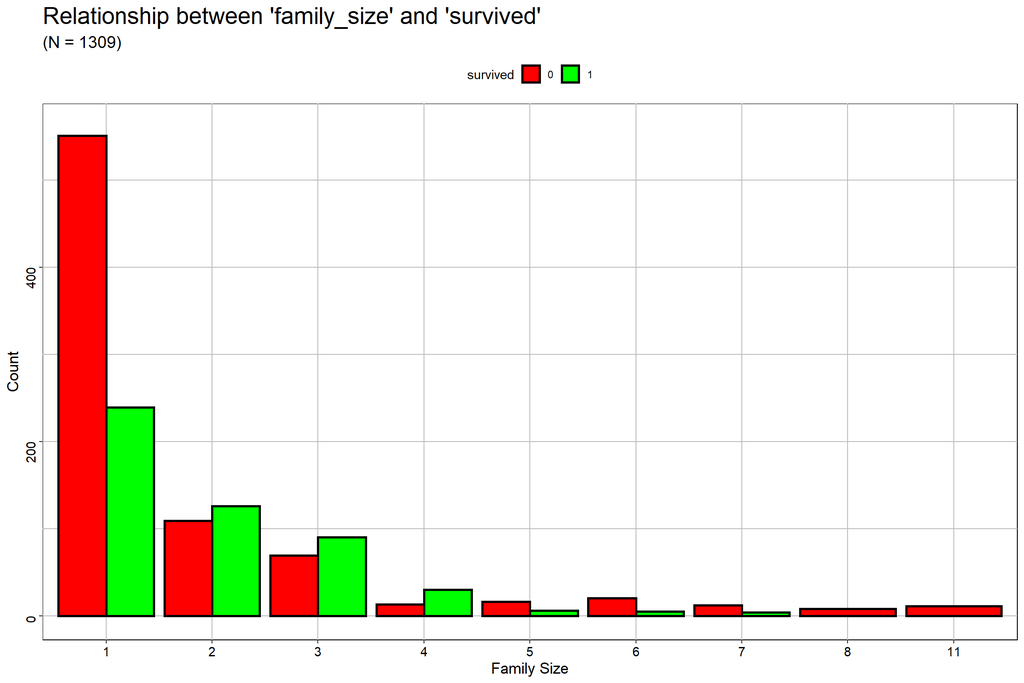

```r
RplotterPkg::create_bar_plot(
    df = survived_family_size_df,
    aes_x = "family_size",
    aes_fill = "survived",
    position = "dodge",
    y_limits = c(0, 560),
    palette_colors = c("red", "green"),
    title = "Relationship between 'family_size' and 'survived'",
    subtitle = "(N = 1309)",
    x_title = "Family Size"
)
```

Appears that *family_size* between 2 to 4 were more likely to survive.

## 4.4 *survived* vs *family_size_dis*

Task: Add a *family_size_dis* column to `full_df` that discretizes *family_size* into 3 levels of `singleton`, `small`, and `large`. Show a crosstabulation of *survived* with *family_size_dis*.

```r
full_df <- full_df %>%
  mutate(
    family_size_dis = case_when(
      family_size == 1 ~ "singleton",
      family_size > 1 & family_size < 5 ~ "small",
      family_size >= 5 ~ "large"
    ),
    family_size_dis = factor(family_size_dis)
  )
table(full_df$survived, full_df$family_size_dis)
##
##     large singleton small
##   0    67       551   191
##   1    15       239   246
```

Small families seem to have a higher count in survival. Show the proportions table.

```r
survived_familysizedis_table <- prop.table(table(full_df$survived, full_df$family_size_dis), 1)
survived_familysizedis_table
##
##          large  singleton      small
##   0 0.08281829 0.68108776 0.23609394
##   1 0.03000000 0.47800000 0.49200000
```

Proportionally `small` families seem to have an edge in survival at 49%.

Task: With a mosaicplot, plot *survived* vs *family_size_dis*.

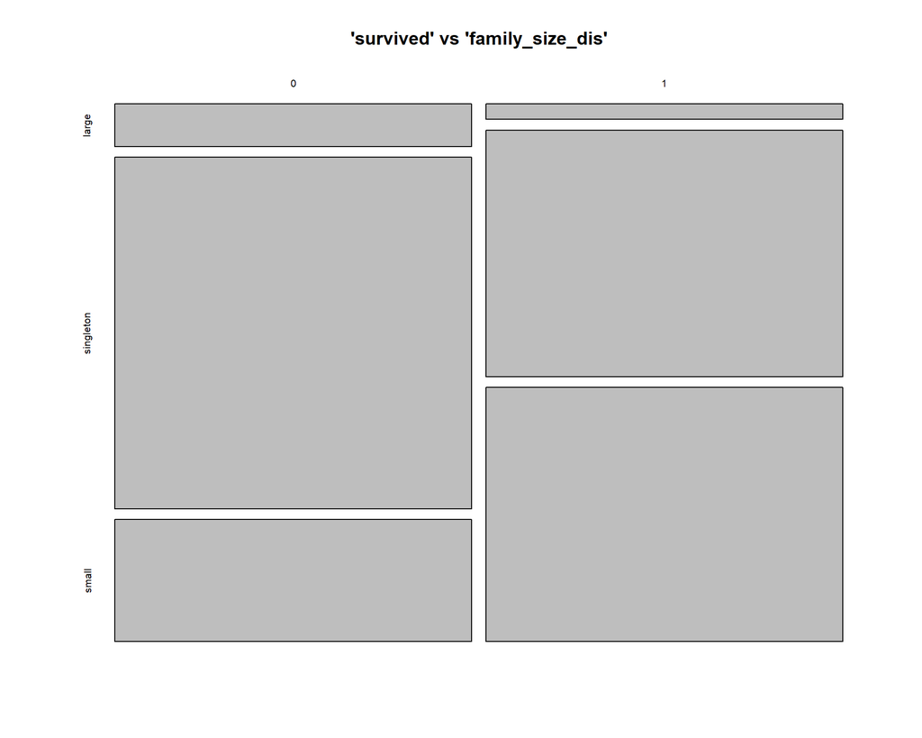

```r
mosaicplot(survived_familysizedis_table, main = "'survived' vs 'family_size_dis'")
```

There is a survival penalty among and large families, but a benefit for passengers in small families.

# 5 Missing data.

## 5.1 Examine missing data for *pclass*, *sex*, *age*, *fare*, and *embarked*

Task: Using the `mice()` package show the pattern of missing data for selected variables.

```r
selected_var_df <- full_df %>%
  select(pclass, sex, age, fare, embarked)
mice::md.pattern(selected_var_df, plot = FALSE)
##      pclass sex fare embarked age
## 1043      1   1    1        1   1   0
## 263       1   1    1        1   0   1
## 2         1   1    1        0   1   1
## 1         1   1    0        1   1   1
##           0   0    1        2 263 266
```

There are 1043 samples that are complete; 263 are missing only *age*; 2 are missing *embarked* and 1 is missing *fare*.

## 5.2 Address *embarked* missing data

Task: Identify the observations that have missing *embarked* values.

```r
missing_embarked_df <- full_df %>%
  filter(is.na(embarked))
missing_embarked_df
## # A tibble: 2 x 21
##   pclass survived name  sex     age sibsp parch ticket  fare cabin embarked
##    <dbl>    <dbl> <chr> <chr> <dbl> <dbl> <dbl> <chr>  <dbl> <chr> <chr>
## 1      1        1 Icar~ fema~    38     0     0 113572    80 B28   <NA>
## 2      1        1 Ston~ fema~    62     0     0 113572    80 B28   <NA>
## # ... with 10 more variables: boat <chr>, body <dbl>, home.dest <chr>,
## #   passenger_id <dbl>, title <chr>, surname <chr>, family_size <dbl>,
## #   family <chr>, deck <chr>, family_size_dis <fct>
```

There are 2 passengers with *embarked* values of `NA`.

Task: Complete a boxplot with *embarked* along the x axis, *fare* along the y axis, and a fill assigned to *pclass* for observations that do not have a missing *embarked* value.

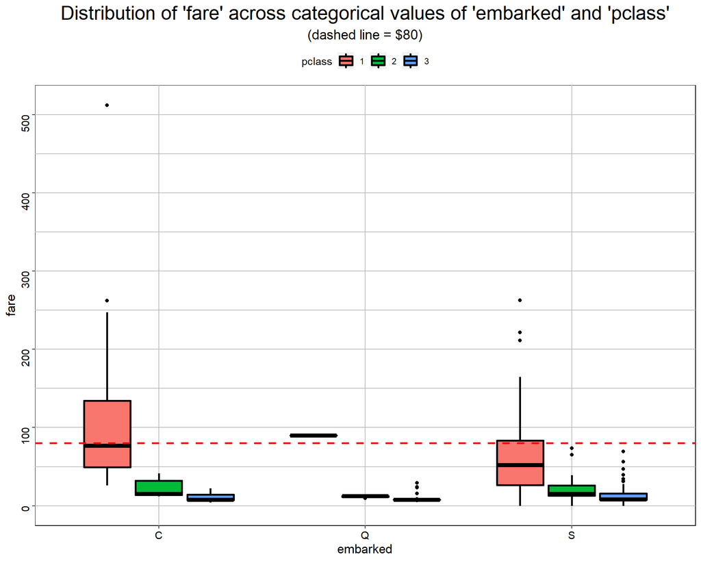

```r
embarked_fare_pclass_df <- full_df %>%
  filter(passenger_id != 169 & passenger_id != 285) %>%
  mutate(pclass = factor(pclass)) %>%
  select(embarked, fare, pclass)

addon <- geom_hline(aes(yintercept = 80), color = "red", linetype = "dashed", lwd = 1)

RplotterPkg::create_box_plot(
  df = embarked_fare_pclass_df,
  aes_x = "embarked",
  aes_y = "fare",
  aes_fill = "pclass",
  title = "Distribution of 'fare' across categorical values of 'embarked' and 'pclass'",
  subtitle = "(dashed line = $80)",
  center_titles = TRUE,
  add_ons = c(addon)
)
```

The red dashed line is showing the location of the 80 dollar *fare* value. From the plot, observations with an *embarked* value of “C” and *pclass*’ of 1, have a mean *fare* close to $80. The 2 missing *embarked* observations had a *pclass* of 1 and a *fare* of 80 which suggest that their *embarked* value is “C”.

Task: Set the *embarked* values for the 2 passengers with missing values to “C”. Check again for *embarked* `NA` values.

```r
full_df$embarked[is.na(full_df$embarked)] <- "C"
missing_embarked_df <- full_df %>%
  filter(is.na(embarked))
missing_embarked_df
## # A tibble: 0 x 21
## # ... with 21 variables: pclass <dbl>, survived <dbl>, name <chr>, sex <chr>,
## #   age <dbl>, sibsp <dbl>, parch <dbl>, ticket <chr>, fare <dbl>, cabin <chr>,
## #   embarked <chr>, boat <chr>, body <dbl>, home.dest <chr>,
## #   passenger_id <dbl>, title <chr>, surname <chr>, family_size <dbl>,
## #   family <chr>, deck <chr>, family_size_dis <fct>
```

## 5.3 Address *fare* missing data

Task: Identify the observations that have missing *fare* values.

```r
missing_fare_df <- full_df %>%
  filter(is.na(fare))
missing_fare_df
## # A tibble: 1 x 21
##   pclass survived name  sex     age sibsp parch ticket  fare cabin embarked
##    <dbl>    <dbl> <chr> <chr> <dbl> <dbl> <dbl> <chr>  <dbl> <chr> <chr>
## 1      3        0 Stor~ male   60.5     0     0 3701      NA <NA>  S
## # ... with 10 more variables: boat <chr>, body <dbl>, home.dest <chr>,
## #   passenger_id <dbl>, title <chr>, surname <chr>, family_size <dbl>,
## #   family <chr>, deck <chr>, family_size_dis <fct>
```

There is 1 passenger with *fare* value of `NA`. The passenger has a *pclass* of 3 and an *embarked* of “S”.

Task: Plot the density of *fare* for observations with a *pclass* of 3 and an *embarked* of “S”. Locate with a dashed line their median value.

```r
pclass_embarked_fare_df <- full_df %>%
  filter(pclass == 3 & embarked == "S") %>%
  select(pclass, embarked, fare)
median_fare <- median(pclass_embarked_fare_df$fare, na.rm = TRUE)
```

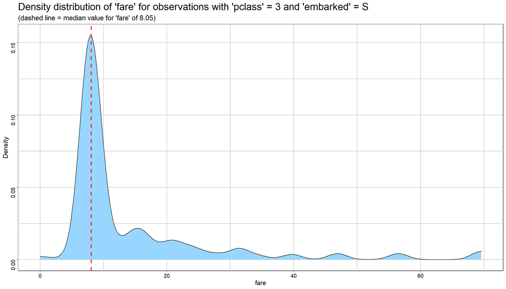

```r
add_on <- geom_vline(aes(xintercept = median_fare), color = "red", linetype = "dashed", lwd = 1)
aplot <- RplotterPkg::create_density_plot(
    df = pclass_embarked_fare_df,
    aes_x = "fare",
    density_fill = "#99d6ff",
    title = "Density distribution of 'fare' for observations with 'pclass' = 3 and 'embarked' = S",
    subtitle = paste0("(dashed line = median value for 'fare' of ",median_fare, ")"),
    add_ons = c(add_on)
)
aplot
```

Task: Set the missing *fare* value of passenger 1226 to the median value of 8.05. Check again for *fare* `NA` values.

```r
full_df[full_df$passenger_id == 1226,]$fare = median_fare
missing_fare_df <- full_df %>%
  filter(is.na(fare)) %>%
  summarise(N = n())
missing_fare_df
## # A tibble: 1 x 1
##       N
##   <int>
## 1     0
```

## 5.4 Address *age* missing data.

Task: Of the 1309 observations, what are the number and percent of missing *age* values.

```r
missing_age_summary_df <- full_df %>%
  summarise(
    missing_age_n = sum(is.na(age)),
    missing_age_percent = mean(is.na(age))*100
  )
missing_age_summary_df$missing_age_n
## [1] 263
missing_age_summary_df$missing_age_percent
## [1] 20.09167
```

Task: Using `mice::mice()` start the imputing process for the *age* variable.

```r
mice_df <- full_df %>%
  select(pclass, sex, age, fare, embarked)
mice_data <- mice::mice(mice_df, seed = 129, printFlag = FALSE)
imput_age <- mice_data$imp$age
imput_complete <- tibble(
  original = full_df$age,
  imput_1 = mice::complete(mice_data, 1)$age,
  imput_2 = mice::complete(mice_data, 2)$age,
  imput_3 = mice::complete(mice_data, 3)$age,
  imput_4 = mice::complete(mice_data, 4)$age,
  imput_5 = mice::complete(mice_data, 5)$age
)
imput_complete_longer_df <- pivot_longer(imput_complete, original:imput_5, names_to = "source", values_to = "age")
glimpse(imput_complete_longer_df)
## Observations: 7,854
## Variables: 2
## $ source <chr> "original", "imput_1", "imput_2", "imput_3", "imput_4", "imp...
## $ age    <dbl> 29.0000, 29.0000, 29.0000, 29.0000, 29.0000, 29.0000, 0.9167...
```

Task: Plot the distributions of *age* from imput_complete_longer_df across levels of *source*.

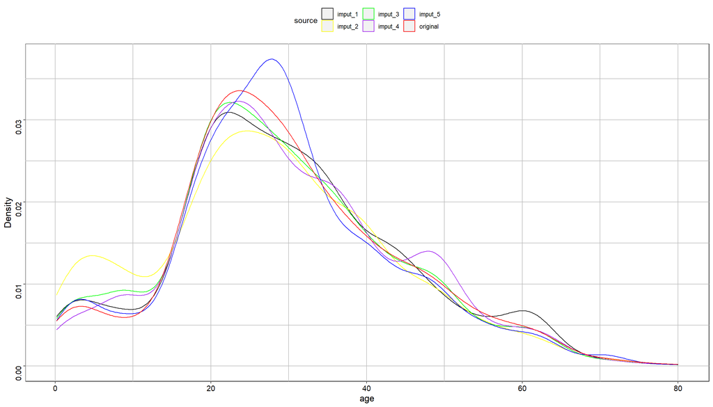

```r
age_df <- imput_complete_longer_df %>%
  filter(!is.na(age))
RplotterPkg::create_density_plot(
    df = age_df,
    aes_x = "age",
    aes_color = "source",
    position = "identity",
    density_alpha = 0.0,
    palette_colors = c("black","yellow","green","purple","blue","red")
)
```

It looks like *imput_3* (color = green) would be a good approximation.

Task: For a closer comparison, let’s do bar charts of the original `age` and the values from *imput_3*.

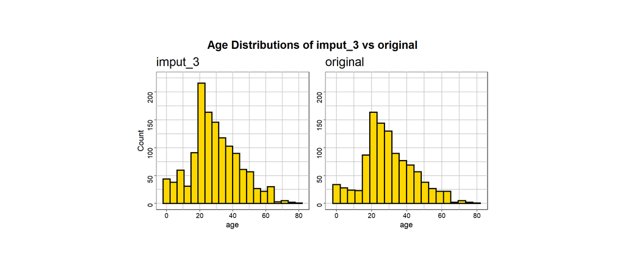

```r
imput_original_imput_3_df <-  imput_complete_longer_df %>%
  filter(factor(source) %in% c("original", "imput_3"))
RplotterPkg::factor_histogram_plot(
  df = imput_original_imput_3_df,
  factor_var = "source",
  y_limits = c(0,225),
  aes_x = "age",
  bar_color = "black",
  bar_fill = "gold",
  title = "Age Distributions of imput_3 vs original"
)
```

Note that the original distribution on the right does not count the 263 passengers with an `age` of NA.

Task: The shapes of imput_3 and the original look close, so let’s replace our *age* variable in `full_df` with the output from the mice model imput_3.

```r
full_df$age <- imput_complete$imput_3
```

## 5.5 Review missing data for *pclass*, *sex*, *age*, *fare*, and *embarked*

Task: From an earlier review there are 1043 samples that are complete; 263 are missing only *age*; 2 are missing *embarked* and 1 is missing *fare*. Do pattern analysis again and see if we have improved the missing values.

```r
selected_var_df <- full_df %>%
  select(pclass, sex, age, fare, embarked)
mice::md.pattern(selected_var_df, plot = FALSE)
##  /\     /\
## {  `---'  }
## {  O   O  }
## ==>  V <==  No need for mice. This data set is completely observed.
##  \  \|/  /
##   `-----'
##      pclass sex age fare embarked
## 1309      1   1   1    1        1 0
##           0   0   0    0        0 0
```

There are now no missing values for our selected variables.

# 6 More relationships and feature engineering

## 6.1 *survived* vs *age* across *sex*

Task: From full_df, make both *survived* and *sex* as factors.

```r
full_df_factored <- full_df %>%
  mutate(
    survived = factor(survived),
    sex = factor(sex)
  )
```

Task: Find the distribution of *age* across values of the factored *sex* and *survived*.

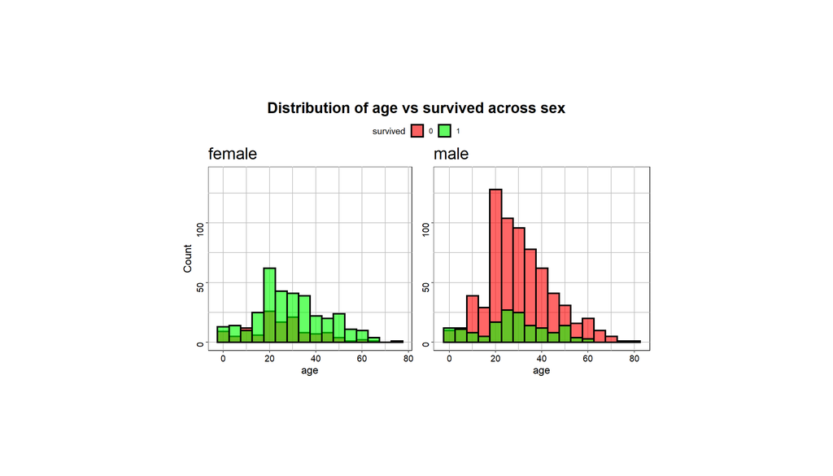

```r
RplotterPkg::factor_histogram_plot(
  df = full_df_factored,
  factor_var = "sex",
  aes_x = "age",
  aes_fill = "survived",
  position = "identity",
  title = "Distribution of age vs survived across sex",
  palette_colors = c("red","green"),
  binwidth = 5,
  y_limits = c(0,140),
  bar_alpha = 0.6
)
```

It appears that females in the older age groups survived better than the older males.

## 6.2 *survived* vs *child*

A “child” is defined as someone under 18 years of age.

Task: For `full_df`, create the column *child* having values “child”/“adult” and show a table of counts between *survived* vs *child*.

```r
full_df <- full_df %>%
  mutate(
    child = if_else(age < 18, "child", "adult"),
    child = factor(child)
  )
table(full_df$survived,full_df$child)
##
##     adult child
##   0   687   122
##   1   402    98
```

Does not look as if being a child helped in survival and is much of a discriminator.

The same table as proportions:

```r
prop.table(table(full_df$survived, full_df$child), 1)
##
##         adult     child
##   0 0.8491965 0.1508035
##   1 0.8040000 0.1960000
```

## 6.3 *survived* vs *child* across *sex*

Task: Show the counts and proportions for *survived* versus *child* across *sex* using the `aggregate()` function.

```r
aggregate(survived ~ child + sex, data = full_df, FUN = sum)
##   child    sex survived
## 1 adult female      277
## 2 child female       62
## 3 adult   male      125
## 4 child   male       36
```

The totals for *survived* versus *child* across *sex*:

```r
aggregate(survived ~ child + sex, data = full_df, FUN = length)
##   child    sex survived
## 1 adult female      372
## 2 child female       94
## 3 adult   male      717
## 4 child   male      126
```

The proportions for *survived* versus *child* across *sex*:

```r
aggregate(survived ~ child + sex, data = full_df, FUN = function(x){sum(x)/length(x)})
##   child    sex  survived
## 1 adult female 0.7446237
## 2 child female 0.6595745
## 3 adult   male 0.1743375
## 4 child   male 0.2857143
```

This shows that females have a good chance to survive, but not much difference among them between `child` or `adult`.

## 6.4 *survived* vs *mother*

A *mother* is a passenger who is:

1. female
2. is over 18
3. has more than 0 children
4. does not have a title ‘Miss’

Task: Create a *mother* variable and show table counts of *survived* vs *mother*.

```r
full_df <- full_df %>%
  mutate(
    mother = if_else(sex == "female" & parch > 0 & age > 18 & title != "Miss", "Mother", "Not Mother"),
    mother = factor(mother)
  )
table(full_df$survived, full_df$mother)
##
##     Mother Not Mother
##   0     20        789
##   1     62        438
```

Being a mother may have helped in survival but is not overwhelming. Show the proportions table:

```r
prop.table(table(full_df$survived, full_df$mother),1)
##
##         Mother Not Mother
##   0 0.02472188 0.97527812
##   1 0.12400000 0.87600000
```

## 6.5 *survived* vs *fare_dis*

Task: Add a *fare_dis* variable to `full_df` with bins less than $10, between $10 and $20, between $20 and $30, and more than $30.

```r
full_df <- full_df %>%
  mutate(
    fare_dis = case_when(
      fare < 10 ~ "<10",
      fare >= 10 & fare < 20 ~ "10-20",
      fare >= 20 & fare < 30 ~ "20-30",
      fare >= 30 ~ ">=30"
    ),
    fare_dis = factor(fare_dis)
  )
```

Task: Find the counts and proportions for *survived* vs *fare_dis*.

```r
table(full_df$survived, full_df$fare_dis)
##
##     <10 >=30 10-20 20-30
##   0 382  148   162   117
##   1 110  202    99    89
```

The proportions for *survived* vs *fare_dis*:

```r
prop.table(table(full_df$survived, full_df$fare_dis), 1)
##
##           <10      >=30     10-20     20-30
##   0 0.4721879 0.1829419 0.2002472 0.1446230
##   1 0.2200000 0.4040000 0.1980000 0.1780000
```

It appears that the highest paying group had a good chance at survival while those < $10 did not fare as well.

# 7 Sample the `full_df` dataframe into `train_df` and `test_df` dataframes.

Task: Factorize *pclass*, *sex*, *embarked*, *title*.

```r
full_df <- full_df %>%
  mutate(
    pclass = factor(pclass),
    sex = factor(sex),
    embarked = factor(embarked),
    title = factor(title)
  )
```

Task: Split `full_df` into a ratio of 70%/30% for train and test respectively.

```r
set.seed(142)
index <- sample(1:1309, size = trunc(0.7 * 1309))
train_df <- full_df %>%
  filter(passenger_id %in% index)
test_df <- full_df %>%
  filter(!(passenger_id %in% index))
```

## 7.1 Save the data frames

Task: Save the data frames for reading in part 2.

```r
write_csv(full_df, "data/full_df.csv")
write_csv(train_df, "data/train_df.csv")
write_csv(test_df, "data/test_df.csv")
```